# Autogenous - LDna combined analysis

Luciano V Cosme

2026-04-06

> **Population label key:** The code labels used in the analysis below correspond to the following manuscript labels: AUT = AUTO, MAN = NON-AUTO, NEW = NON-AUTO-FIELD.

```r
# Load tidyverse FIRST to avoid rlang version conflict
library(tidyverse)
library(here)
library(scales)
library(ggrepel)

# Then add LDna v.2.15 library path and load
.libPaths(c("/workspace/lib/ldna_v215", .libPaths()))
library(LDna)
library(reshape2)
library(writexl)
```

## 6. Combine the chromosomal data

Clean env and memory

```r
# Remove all objects from the environment
rm(list = ls())

# Run the garbage collector to free up memory
gc()
```

```
##           used (Mb) gc trigger  (Mb) max used  (Mb)
## Ncells 1176646 62.9    2232931 119.3  2232931 119.3
## Vcells 1972919 15.1    8388608  64.0  3453300  26.4
```

Read the plotting data for NEW and AUT

```r
# NEW
NEW1 <- readRDS(here("output", "ldna", "pop", "chr1", "NEW_plot2.rds")) |> mutate(Population = "NEW")
NEW2 <- readRDS(here("output", "ldna", "pop", "chr2", "NEW_plot2.rds")) |> mutate(Population = "NEW")
NEW3 <- readRDS(here("output", "ldna", "pop", "chr3", "NEW_plot2.rds")) |> mutate(Population = "NEW")

# AUT
AUT1 <- readRDS(here("output", "ldna", "pop", "chr1", "AUT_plot2.rds")) |> mutate(Population = "AUT")
AUT2 <- readRDS(here("output", "ldna", "pop", "chr2", "AUT_plot2.rds")) |> mutate(Population = "AUT")
AUT3 <- readRDS(here("output", "ldna", "pop", "chr3", "AUT_plot2.rds")) |> mutate(Population = "AUT")
```

Bind the objects

```r
albo <- rbind(NEW1, NEW2, NEW3, AUT1, AUT2, AUT3)

head(albo)
```

```
##   Chromosome   Cluster   r2    Start      End nSegments nSNPs Population
## 1          1 2098_0.81 0.81  1671072 16303506       225  3339        NEW
## 2          1 2098_0.81 0.81 16308219 16458676       225  3339        NEW
## 3          1 2098_0.81 0.81 16560013 16688706       225  3339        NEW
## 4          1 2098_0.81 0.81 16723593 17338376       225  3339        NEW
## 5          1 2098_0.81 0.81 17376443 17614762       225  3339        NEW
## 6          1 2098_0.81 0.81 17763447 19491473       225  3339        NEW
```

We can create a table

```r
table1 <- albo |>
  mutate(Size = End - Start) |>
  dplyr::select(
    Population, Chromosome, Cluster, r2, nSegments, nSNPs, Start, End, Size
  ) |>
  arrange(Population, Chromosome, Start)
head(table1)
```

```
##   Population Chromosome   Cluster   r2 nSegments nSNPs    Start      End
## 1        AUT          1 1927_0.68 0.68        18    43  1619834  2269308
## 2        AUT          1 1877_0.71 0.71        21    46  3766945  4238554
## 3        AUT          1 1946_0.66 0.66        23    30  4981859  5217622
## 4        AUT          1 1877_0.71 0.71        21    46  5443736 10957198
## 5        AUT          1 1980_0.63 0.63        20    31 11125830 11276238
## 6        AUT          1 1559_0.84 0.84        33    42 11638599 12192074
##      Size
## 1  649474
## 2  471609
## 3  235763
## 4 5513462
## 5  150408
## 6  553475
```

We can focus on LD blocks equal or bigger than 1Mb

```r
table1 <- table1 %>%
  dplyr::filter(Size >= 1000000) %>%
  dplyr::mutate(`Size (Mb)` = round(Size / 1000000, 2)) # %>%
  # dplyr::select(Size)
head(table1)
```

```
##   Population Chromosome   Cluster   r2 nSegments nSNPs     Start       End
## 1        AUT          1 1877_0.71 0.71        21    46   5443736  10957198
## 2        AUT          1 1763_0.77 0.77        30    61  87157392  88199259
## 3        AUT          1 1763_0.77 0.77        30    61  88919855  90254445
## 4        AUT          1 1628_0.82 0.82        26    50 119130691 120305920
## 5        AUT          1 1971_0.64 0.64        29    90 138373561 140570398
## 6        AUT          1 1651_0.81 0.81       519   679 151544898 152551833
##      Size Size (Mb)
## 1 5513462      5.51
## 2 1041867      1.04
## 3 1334590      1.33
## 4 1175229      1.18
## 5 2196837      2.20
## 6 1006935      1.01
```

Create table

```r
knitr::kable(table1)
```

| Population | Chromosome | Cluster | r2 | nSegments | nSNPs | Start | End | Size | Size (Mb) |
| --- | --- | --- | --- | --- | --- | --- | --- | --- | --- |
| AUT | 1 | 1877_0.71 | 0.71 | 21 | 46 | 5443736 | 10957198 | 5513462 | 5.51 |
| AUT | 1 | 1763_0.77 | 0.77 | 30 | 61 | 87157392 | 88199259 | 1041867 | 1.04 |
| AUT | 1 | 1763_0.77 | 0.77 | 30 | 61 | 88919855 | 90254445 | 1334590 | 1.33 |
| AUT | 1 | 1628_0.82 | 0.82 | 26 | 50 | 119130691 | 120305920 | 1175229 | 1.18 |
| AUT | 1 | 1971_0.64 | 0.64 | 29 | 90 | 138373561 | 140570398 | 2196837 | 2.20 |
| AUT | 1 | 1651_0.81 | 0.81 | 519 | 679 | 151544898 | 152551833 | 1006935 | 1.01 |
| AUT | 1 | 1673_0.8 | 0.8 | 395 | 486 | 179031717 | 180129204 | 1097487 | 1.10 |
| AUT | 1 | 1656_0.81 | 0.81 | 536 | 691 | 242081344 | 243905804 | 1824460 | 1.82 |
| AUT | 1 | 1656_0.81 | 0.81 | 536 | 691 | 247353243 | 249207733 | 1854490 | 1.85 |
| AUT | 1 | 1673_0.8 | 0.8 | 395 | 486 | 260581858 | 262016624 | 1434766 | 1.43 |
| AUT | 1 | 1976_0.63 | 0.63 | 18 | 90 | 266160984 | 270116064 | 3955080 | 3.96 |
| AUT | 1 | 1934_0.67 | 0.67 | 19 | 40 | 282087582 | 284546412 | 2458830 | 2.46 |
| AUT | 2 | 3065_0.81 | 0.81 | 1933 | 4652 | 49798927 | 52237467 | 2438540 | 2.44 |
| AUT | 2 | 3065_0.81 | 0.81 | 1933 | 4652 | 101467688 | 102825816 | 1358128 | 1.36 |
| AUT | 2 | 3065_0.81 | 0.81 | 1933 | 4652 | 103572137 | 106204056 | 2631919 | 2.63 |
| AUT | 2 | 3065_0.81 | 0.81 | 1933 | 4652 | 124168259 | 126538488 | 2370229 | 2.37 |
| AUT | 2 | 3065_0.81 | 0.81 | 1933 | 4652 | 130361623 | 131660157 | 1298534 | 1.30 |
| AUT | 2 | 3065_0.81 | 0.81 | 1933 | 4652 | 137777373 | 138981409 | 1204036 | 1.20 |
| AUT | 2 | 3065_0.81 | 0.81 | 1933 | 4652 | 141440521 | 142703746 | 1263225 | 1.26 |
| AUT | 2 | 3065_0.81 | 0.81 | 1933 | 4652 | 149078628 | 153093408 | 4014780 | 4.01 |
| AUT | 2 | 3065_0.81 | 0.81 | 1933 | 4652 | 153767456 | 155771880 | 2004424 | 2.00 |
| AUT | 2 | 3066_0.81 | 0.81 | 797 | 989 | 156275046 | 158102348 | 1827302 | 1.83 |
| AUT | 2 | 3533_0.6 | 0.6 | 33 | 72 | 328800255 | 329979871 | 1179616 | 1.18 |
| AUT | 2 | 3531_0.61 | 0.61 | 21 | 31 | 333084727 | 334205193 | 1120466 | 1.12 |
| AUT | 2 | 3215_0.78 | 0.78 | 97 | 324 | 390518548 | 391668996 | 1150448 | 1.15 |
| AUT | 2 | 3215_0.78 | 0.78 | 97 | 324 | 391711273 | 392777580 | 1066307 | 1.07 |
| AUT | 2 | 3215_0.78 | 0.78 | 97 | 324 | 397107735 | 401367529 | 4259794 | 4.26 |
| AUT | 2 | 3215_0.78 | 0.78 | 97 | 324 | 405893739 | 407224834 | 1331095 | 1.33 |
| AUT | 2 | 3138_0.8 | 0.8 | 26 | 61 | 407321663 | 411100836 | 3779173 | 3.78 |
| AUT | 2 | 3138_0.8 | 0.8 | 26 | 61 | 411409101 | 412997990 | 1588889 | 1.59 |

[output cut: 240 more lines]

We can create a facet plot now for all chromosomes

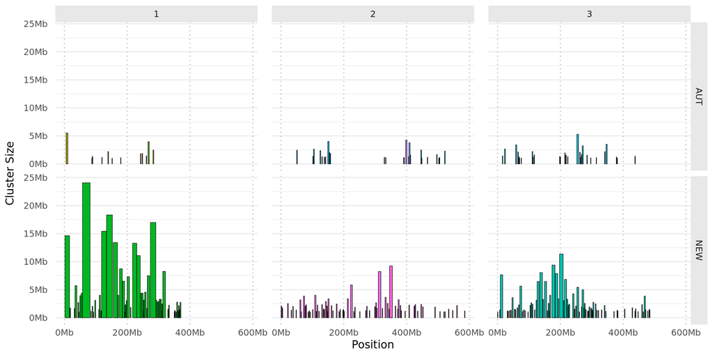

```r
# To plot only clusters equal or bigger than 1Mb
albo2 <- table1 |> dplyr::filter(Size >= 1000000)

# Function to format numbers as Mb
label_mb <- function(x) {
  sprintf("%.0fMb", x / 1e6)
}

# Plot it
ggplot(albo2, aes(xmin = Start, xmax = End, ymin = 0, ymax = Size)) +
  geom_rect(aes(fill = as.factor(Cluster)), color = "black", linewidth = 0.2) +
  scale_x_continuous(labels = label_mb, breaks = pretty_breaks(n = 3)) +
  scale_y_continuous(labels = label_mb, breaks = pretty_breaks(n = 5)) +
  labs(x = "Position", y = "Cluster Size") +
  theme_minimal() +
  theme(
    axis.text.y = element_text(margin = margin(t = 0, r = 5, b = 0, l = 5)),
    axis.ticks.y = element_blank(),
    panel.grid.major.x = element_line(color = "gray", linetype = "dotted"),
    strip.background = element_rect(fill = "#e8e8e8", colour = NA),
    panel.grid.minor.x = element_blank(),
    legend.position = "none",
    panel.spacing.x = unit(1, "lines")  # Adjust the unit and number to increase space as needed
  ) +
  facet_grid(Population ~ Chromosome, scales = "fixed", space = "fixed") +
  guides(fill = "none")
```

```r
# Use ggsave to save the plot as a PDF
# ggsave(
#   filename = here("output", "ldna", "AUT_NEW_fixed.pdf"),
#   device = "pdf",
#   width = 10,
#   height = 5,
#   units = "in"
# )
```

Make each plot with different scales

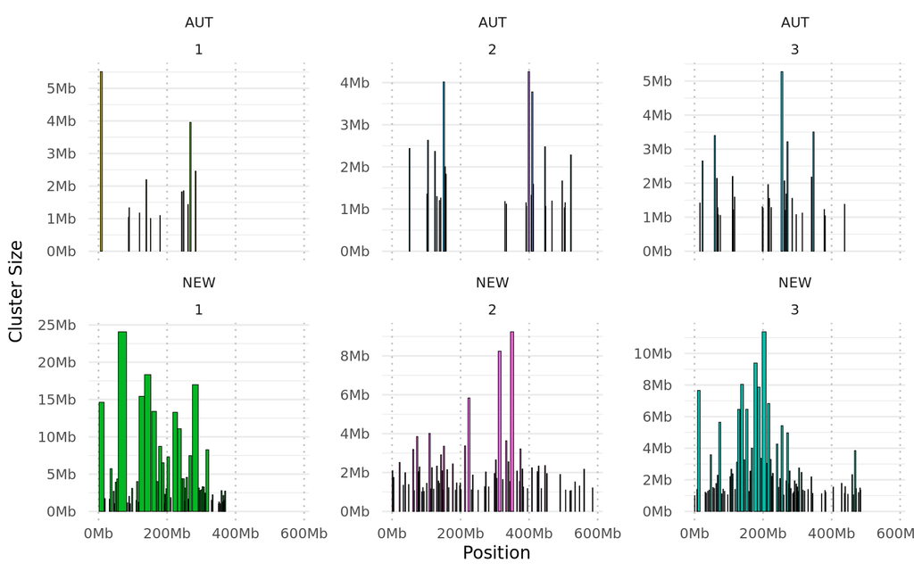

```r
# Plot it
ggplot(albo2, aes(xmin = Start, xmax = End, ymin = 0, ymax = Size)) +
  geom_rect(aes(fill = as.factor(Cluster)), color = "black", linewidth = 0.2) +
  scale_x_continuous(labels = label_mb, breaks = pretty_breaks(n = 3)) +
  scale_y_continuous(labels = label_mb, breaks = pretty_breaks(n = 5)) +
  labs(x = "Position", y = "Cluster Size") +
  theme_minimal() +
  theme(
    axis.text.y = element_text(margin = margin(t = 0, r = 5, b = 0, l = 5)),
    axis.ticks.y = element_blank(),
    panel.grid.major.x = element_line(color = "gray", linetype = "dotted"),
    panel.grid.minor.x = element_blank(),
    # strip.background = element_rect(fill = "#e8e8e8", colour = NA),
    legend.position = "none",
    panel.spacing.x = unit(1, "lines")
  ) +
  facet_wrap(~ Population + Chromosome, scales = "free_y", ncol = 3) +  # Free y scale, and each chromosome gets its own row
  guides(fill = "none")
```

```r
# Use ggsave to save the plot as a PDF
# ggsave(
#   filename = here("output", "ldna", "AUT_NEW_free.pdf"),
#   device = "pdf",
#   width = 8,
#   height = 5,
#   units = "in"
# )
```

We can also remove the large clusters and plot with fixed scale to look at the cluster between 1 and 10Mb

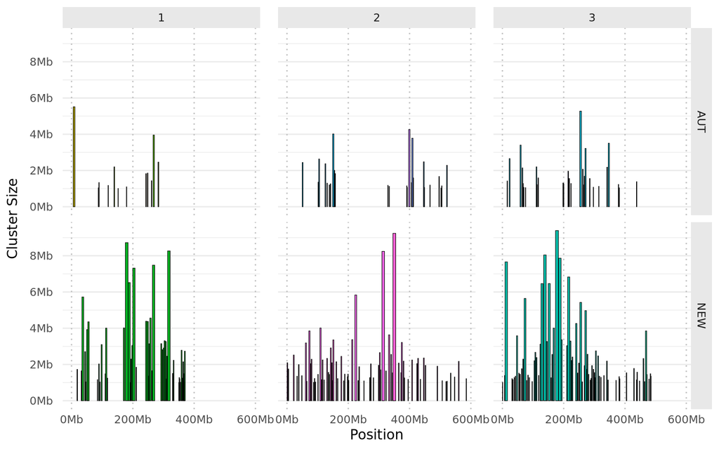

```r
# To plot only clusters equal or bigger than 1Mb but less that 10Mb
albo3 <- albo2 |> dplyr::filter(Size >= 1000000, Size <= 10000000)


# Plot it
ggplot(albo3, aes(xmin = Start, xmax = End, ymin = 0, ymax = Size)) +
  geom_rect(aes(fill = as.factor(Cluster)), color = "black", linewidth = 0.2) +
  scale_x_continuous(labels = label_mb, breaks = pretty_breaks(n = 3)) +
  scale_y_continuous(labels = label_mb, breaks = pretty_breaks(n = 5)) +
  labs(x = "Position", y = "Cluster Size") +
  theme_minimal() +
  theme(
    axis.text.y = element_text(margin = margin(t = 0, r = 5, b = 0, l = 5)),
    axis.ticks.y = element_blank(),
    panel.grid.major.x = element_line(color = "gray", linetype = "dotted"),
    strip.background = element_rect(fill = "#e8e8e8", colour = NA),
    panel.grid.minor.x = element_blank(),
    legend.position = "none",
    panel.spacing.x = unit(1, "lines")  # Adjust the unit and number to increase space as needed
  ) +
  facet_grid(Population ~ Chromosome, scales = "fixed", space = "fixed") +
  guides(fill = "none")
```

```r
# Use ggsave to save the plot as a PDF
# ggsave(
#   filename = here("output", "ldna", "AUT_NEW_fixed_1_to_10Mb.pdf"),
#   device = "pdf",
#   width = 8,
#   height = 5,
#   units = "in"
# )
```

We could do the analysis by sex, but we only have 13 females and 15 males in AUT. Perhaps we could use the same number of samples for each. However, the sample size will be too small still.

## 7. Plot SNPs on DE genes with LD blocks

```r
snps_scan <-
  read.table(
    # here("output", "pcadapt", "man_aut_common_SNPs_pcadapt_outflank.txt"),
    here("output", "snpeff", "SNPs_79_DE.txt"),
    stringsAsFactors = FALSE
  ) |>
  dplyr::rename(
    SNP = V1
  )

head(snps_scan)
```

```
##            SNP
## 1 AX-583054970
## 2 AX-583055828
## 3 AX-583093532
## 4 AX-583142560
## 5 AX-583237406
## 6 AX-583279927
```

Import bim file

```r
# Import the function
source(
  here(
    "notebooks", "helpers", "import_bim.R")
)

# Import the data
snps <- import_bim(here("output", "ldna", "files", "file1.bim"))

# Check it
head(snps)
```

```
## # A tibble: 6 x 6
##   Scaffold SNP             Cm Position Allele1 Allele2
##   <chr>    <chr>        <int>    <dbl> <chr>   <chr>
## 1 1        AX-581444870     0    97856 C       T
## 2 1        AX-583035083     0   305518 A       G
## 3 1        AX-583035102     0   308124 A       G
## 4 1        AX-583033342     0   315059 C       G
## 5 1        AX-583035163     0   315386 A       G
## 6 1        AX-583033356     0   315674 C       T
```

Merge the objects

```r
merged_snps <- inner_join(snps_scan, snps, by = "SNP") |>
  dplyr::rename(
    Chromosome = Scaffold
  )
head(merged_snps)
```

```
##            SNP Chromosome Cm Position Allele1 Allele2
## 1 AX-583054970          1  0  5342242       G       A
## 2 AX-583055828          1  0  6260504       A       G
## 3 AX-583093532          1  0 18373267       C       T
## 4 AX-583142560          1  0 33012482       T       C
## 5 AX-583237406          1  0 66299838       T       C
## 6 AX-583279927          1  0 80133483       A       G
```

We can add them as lines in the plot

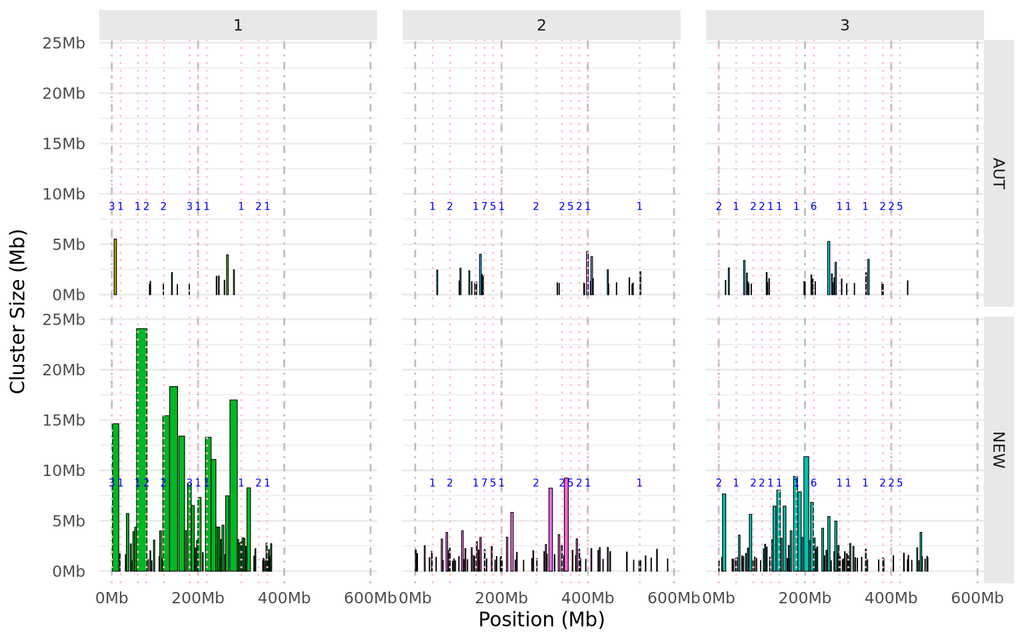

```r
# First, create a new data frame with 1Mb windows and count SNPs in each window
merged_snps$Window <- floor(merged_snps$Position / 20e6) * 20e6 # 20mb
snp_counts <- merged_snps %>%
  group_by(Chromosome, Window) %>%
  summarize(SNP_count = n(), .groups = 'drop')

# Now, add this SNP information to the plot
snp_plot <- ggplot() +
  geom_rect(data = albo2, aes(xmin = Start, xmax = End, ymin = 0, ymax = Size, fill = as.factor(Cluster)),
            color = "black", linewidth = 0.2) +
  geom_vline(data = snp_counts, aes(xintercept = Window + 0.5e6), color = "pink", linetype = "dotted", linewidth = 0.5) +
  geom_text(data = snp_counts, aes(x = Window + 0.5e6, y = 8e6, label = SNP_count), vjust = -0.5, color = "blue", size = 2) +
  scale_x_continuous(labels = label_mb, breaks = pretty_breaks(n = 3)) +
  scale_y_continuous(labels = label_mb, breaks = pretty_breaks(n = 5)) +
  labs(x = "Position (Mb)", y = "Cluster Size (Mb)") +
  theme_minimal() +
  theme(
    axis.text.y = element_text(margin = margin(t = 0, r = 5, b = 0, l = 5)),
    axis.ticks.y = element_blank(),
    panel.grid.major.x = element_line(color = "gray", linetype = "dotdash"),
    strip.background = element_rect(fill = "#e8e8e8", colour = NA),
    panel.grid.minor.x = element_blank(),
    legend.position = "none",
    panel.spacing.x = unit(1, "lines")
  ) +
  facet_grid(Population ~ Chromosome, scales = "fixed", space = "fixed")

# Display the plot
print(snp_plot)
```

```r
#
# # Use ggsave to save the plot as a PDF
# ggsave(
#   filename = here("output", "ldna", "linkage_snps_genes_de.pdf"),
#   device = "pdf",
#   width = 8,
#   height = 5,
#   units = "in"
# )
```

Find the non-overlapping clusters

```r
# Split the data into two subsets based on Population
albo_NEW <- subset(albo2, Population == "NEW")
albo_AUT <- subset(albo2, Population == "AUT")

# Function to find non-overlapping clusters
find_non_overlapping_clusters <- function(new_clusters, aut_clusters) {
  non_overlapping <- vector("list", length(new_clusters$Chromosome))
  names(non_overlapping) <- unique(new_clusters$Chromosome)

  for (chr in unique(new_clusters$Chromosome)) {
    new_chrom_clusters <- new_clusters[new_clusters$Chromosome == chr, ]
    aut_chrom_clusters <- aut_clusters[aut_clusters$Chromosome == chr, ]

    non_overlap <- vector("list", nrow(new_chrom_clusters))

    for (i in 1:nrow(new_chrom_clusters)) {
      overlaps <- any(aut_chrom_clusters$Start <= new_chrom_clusters$End[i] & aut_chrom_clusters$End >= new_chrom_clusters$Start[i])
      if (!overlaps) {
        non_overlap[[i]] <- new_chrom_clusters[i, ]
      }
    }

    non_overlapping[[chr]] <- do.call(rbind, non_overlap)
  }

  do.call(rbind, non_overlapping)
}

# Find non-overlapping clusters
non_overlapping_clusters <- find_non_overlapping_clusters(albo_NEW, albo_AUT)

# View the non-overlapping clusters
non_overlapping_clusters
```

```
##       Population Chromosome   Cluster   r2 nSegments nSNPs     Start       End
## 1.67         NEW          1 2098_0.81 0.81       225  3339  17763447  19491473
## 1.68         NEW          1 2098_0.81 0.81       225  3339  31462771  33110064
## 1.69         NEW          1 2098_0.81 0.81       225  3339  33812253  39535721
## 1.70         NEW          1 2098_0.81 0.81       225  3339  42912079  45617370
## 1.71         NEW          1 2098_0.81 0.81       225  3339  45813378  46852266
## 1.72         NEW          1 2098_0.81 0.81       225  3339  49058652  52982032
## 1.73         NEW          1 2098_0.81 0.81       225  3339  53104692  57458477
## 1.74         NEW          1 2098_0.81 0.81       225  3339  57603304  81674467
## 1.75         NEW          1 2098_0.81 0.81       225  3339  84125006  85286331
## 1.77         NEW          1 2257_0.78 0.78        21    49  92128407  93161109
## 1.78         NEW          1 2098_0.81 0.81       225  3339  96662783  99757810
## 1.79         NEW          1 2098_0.81 0.81       225  3339 109454635 110939058
## 1.80         NEW          1 2098_0.81 0.81       225  3339 111088239 115093306
## 1.81         NEW          1 2098_0.81 0.81       225  3339 116539985 117786853
## 1.84         NEW          1 2098_0.81 0.81       225  3339 155511543 168919506
## 1.85         NEW          1 2098_0.81 0.81       225  3339 169035292 173049491
## 1.87         NEW          1 2098_0.81 0.81       225  3339 184822512 191340592
## 1.88         NEW          1 2098_0.81 0.81       225  3339 191491743 192497058
## 1.89         NEW          1 2098_0.81 0.81       225  3339 193238959 195536041
## 1.90         NEW          1 2098_0.81 0.81       225  3339 196644737 199686032
## 1.91         NEW          1 2098_0.81 0.81       225  3339 199758742 207076243
## 1.92         NEW          1 2098_0.81 0.81       225  3339 210193969 212041495
## 1.93         NEW          1 2098_0.81 0.81       225  3339 217126621 230413950
## 1.94         NEW          1 2098_0.81 0.81       225  3339 230429247 241512774
## 1.97         NEW          1 2098_0.81 0.81       225  3339 250638063 252000239
## 1.98         NEW          1 2098_0.81 0.81       225  3339 252144386 255284772
## 1.99         NEW          1 2098_0.81 0.81       225  3339 255471960 260032529
## 1.100        NEW          1 2098_0.81 0.81       225  3339 262169514 263823952
## 1.103        NEW          1 2098_0.81 0.81       225  3339 291128858 294274102
## 1.104        NEW          1 2098_0.81 0.81       225  3339 294683970 297498464
## 1.105        NEW          1 2098_0.81 0.81       225  3339 299222427 302129356
## 1.106        NEW          1 2098_0.81 0.81       225  3339 302199736 305506598
## 1.107        NEW          1 2098_0.81 0.81       225  3339 305564825 308828617
## 1.108        NEW          1 2098_0.81 0.81       225  3339 308845316 310046723
## 1.109        NEW          1 2098_0.81 0.81       225  3339 310436955 312893712
## 1.110        NEW          1 2098_0.81 0.81       225  3339 313386794 321651633
## 1.111        NEW          1 2098_0.81 0.81       225  3339 329288148 330792056
## 1.112        NEW          1 2098_0.81 0.81       225  3339 331903843 334134626
## 1.113        NEW          1 2098_0.81 0.81       225  3339 349747385 350752606
```

[output cut: 289 more lines]

```
## 3.252  1288333      1.29
## 3.253  1387549      1.39
## 3.256  1121920      1.12
## 3.258  1208393      1.21
## 3.259  1540907      1.54
## 3.260  1779564      1.78
## 3.262  1573787      1.57
## 3.263  1087023      1.09
## 3.264  2326084      2.33
## 3.265  1051794      1.05
## 3.266  3849878      3.85
## 3.267  1443616      1.44
## 3.268  1196353      1.20
## 3.269  1487231      1.49
## 3.270  1352458      1.35
```

Sanity check: Second way to get it

```r
# Function to find non-overlapping segments
find_non_overlapping_segments <- function(new_clusters, aut_clusters) {
  non_overlapping <- list()

  for (chr in unique(new_clusters$Chromosome)) {
    new_chrom_segments <- new_clusters[new_clusters$Chromosome == chr, ]
    aut_chrom_segments <- aut_clusters[aut_clusters$Chromosome == chr, ]

    non_overlap <- list()

    for (i in 1:nrow(new_chrom_segments)) {
      overlaps <- FALSE
      for (j in 1:nrow(aut_chrom_segments)) {
        if (new_chrom_segments$Start[i] <= aut_chrom_segments$End[j] && new_chrom_segments$End[i] >= aut_chrom_segments$Start[j]) {
          overlaps <- TRUE
          break
        }
      }

      if (!overlaps) {
        non_overlap <- c(non_overlap, list(new_chrom_segments[i, ]))
      }
    }

    non_overlapping[[chr]] <- do.call(rbind, non_overlap)
  }

  do.call(rbind, non_overlapping)
}

# Find non-overlapping segments
non_overlapping_segments <- find_non_overlapping_segments(albo_NEW, albo_AUT)

# View the non-overlapping segments
non_overlapping_segments
```

```
##     Population Chromosome   Cluster   r2 nSegments nSNPs     Start       End
## 67         NEW          1 2098_0.81 0.81       225  3339  17763447  19491473
## 68         NEW          1 2098_0.81 0.81       225  3339  31462771  33110064
## 69         NEW          1 2098_0.81 0.81       225  3339  33812253  39535721
## 70         NEW          1 2098_0.81 0.81       225  3339  42912079  45617370
## 71         NEW          1 2098_0.81 0.81       225  3339  45813378  46852266
## 72         NEW          1 2098_0.81 0.81       225  3339  49058652  52982032
## 73         NEW          1 2098_0.81 0.81       225  3339  53104692  57458477
## 74         NEW          1 2098_0.81 0.81       225  3339  57603304  81674467
## 75         NEW          1 2098_0.81 0.81       225  3339  84125006  85286331
## 77         NEW          1 2257_0.78 0.78        21    49  92128407  93161109
## 78         NEW          1 2098_0.81 0.81       225  3339  96662783  99757810
## 79         NEW          1 2098_0.81 0.81       225  3339 109454635 110939058
## 80         NEW          1 2098_0.81 0.81       225  3339 111088239 115093306
## 81         NEW          1 2098_0.81 0.81       225  3339 116539985 117786853
```

[output cut: 329 more lines]

```r
# Function to find unique non-overlapping clusters for each population
find_unique_clusters <- function(population1, population2) {
  unique_clusters <- list()

  for (chr in unique(population1$Chromosome)) {
    pop1_chrom_clusters <- population1[population1$Chromosome == chr, ]
    pop2_chrom_clusters <- population2[population2$Chromosome == chr, ]

    unique_clusters_chr <- list()

    for (i in 1:nrow(pop1_chrom_clusters)) {
      overlaps <- any(
        pop2_chrom_clusters$Start <= pop1_chrom_clusters$End[i] &
        pop2_chrom_clusters$End >= pop1_chrom_clusters$Start[i]
      )

      if (!overlaps) {
        unique_clusters_chr <- c(unique_clusters_chr, list(pop1_chrom_clusters[i, ]))
      }
    }

    if (length(unique_clusters_chr) > 0) {
      unique_clusters[[chr]] <- do.call(rbind, unique_clusters_chr)
    }
  }

  do.call(rbind, unique_clusters)
}

# Find unique non-overlapping clusters for NEW and AUT populations
unique_clusters_NEW <- find_unique_clusters(albo2[albo2$Population == "NEW",], albo2[albo2$Population == "AUT",])
unique_clusters_AUT <- find_unique_clusters(albo2[albo2$Population == "AUT",], albo2[albo2$Population == "NEW",])

# View the unique non-overlapping clusters for each population
unique_clusters_NEW
```

```
##     Population Chromosome   Cluster   r2 nSegments nSNPs     Start       End
## 67         NEW          1 2098_0.81 0.81       225  3339  17763447  19491473
## 68         NEW          1 2098_0.81 0.81       225  3339  31462771  33110064
## 69         NEW          1 2098_0.81 0.81       225  3339  33812253  39535721
## 70         NEW          1 2098_0.81 0.81       225  3339  42912079  45617370
## 71         NEW          1 2098_0.81 0.81       225  3339  45813378  46852266
## 72         NEW          1 2098_0.81 0.81       225  3339  49058652  52982032
## 73         NEW          1 2098_0.81 0.81       225  3339  53104692  57458477
## 74         NEW          1 2098_0.81 0.81       225  3339  57603304  81674467
## 75         NEW          1 2098_0.81 0.81       225  3339  84125006  85286331
## 77         NEW          1 2257_0.78 0.78        21    49  92128407  93161109
## 78         NEW          1 2098_0.81 0.81       225  3339  96662783  99757810
## 79         NEW          1 2098_0.81 0.81       225  3339 109454635 110939058
## 80         NEW          1 2098_0.81 0.81       225  3339 111088239 115093306
## 81         NEW          1 2098_0.81 0.81       225  3339 116539985 117786853
```

[output cut: 329 more lines]

```r
unique_clusters_AUT
```

```
##    Population Chromosome   Cluster   r2 nSegments nSNPs     Start       End
## 2         AUT          1 1763_0.77 0.77        30    61  87157392  88199259
## 10        AUT          1  1673_0.8  0.8       395   486 260581858 262016624
## 13        AUT          2 3065_0.81 0.81      1933  4652  49798927  52237467
## 15        AUT          2 3065_0.81 0.81      1933  4652 103572137 106204056
## 16        AUT          2 3065_0.81 0.81      1933  4652 124168259 126538488
## 21        AUT          2 3065_0.81 0.81      1933  4652 153767456 155771880
## 22        AUT          2 3066_0.81 0.81       797   989 156275046 158102348
## 23        AUT          2  3533_0.6  0.6        33    72 328800255 329979871
## 25        AUT          2 3215_0.78 0.78        97   324 390518548 391668996
## 26        AUT          2 3215_0.78 0.78        97   324 391711273 392777580
## 27        AUT          2 3215_0.78 0.78        97   324 397107735 401367529
## 30        AUT          2  3138_0.8  0.8        26    61 411409101 412997990
## 32        AUT          2 3065_0.81 0.81      1933  4652 447843218 448906645
## 33        AUT          2 3065_0.81 0.81      1933  4652 466090283 467282916
```

[output cut: 39 more lines]

Plot it

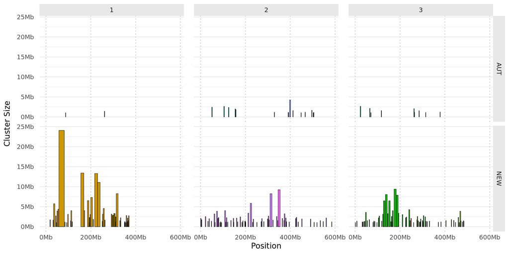

```r
# Combine the two data frames
combined_clusters <- rbind(unique_clusters_NEW, unique_clusters_AUT)


# Function to format numbers as Mb
label_mb <- function(x) {
  sprintf("%.0fMb", x / 1e6)
}

# Plot it
ggplot(combined_clusters, aes(xmin = Start, xmax = End, ymin = 0, ymax = Size)) +
  geom_rect(aes(fill = as.factor(Cluster)), color = "black", linewidth = 0.2) +
  scale_x_continuous(labels = label_mb, breaks = pretty_breaks(n = 3)) +
  scale_y_continuous(labels = label_mb, breaks = pretty_breaks(n = 5)) +
  labs(x = "Position", y = "Cluster Size") +
  theme_minimal() +
  theme(
    axis.text.y = element_text(margin = margin(t = 0, r = 5, b = 0, l = 5)),
    axis.ticks.y = element_blank(),
    panel.grid.major.x = element_line(color = "gray", linetype = "dotted"),
    strip.background = element_rect(fill = "#e8e8e8", colour = NA),
    panel.grid.minor.x = element_blank(),
    legend.position = "none",
    panel.spacing.x = unit(1, "lines")  # Adjust the unit and number to increase space as needed
  ) +
  facet_grid(Population ~ Chromosome, scales = "fixed", space = "fixed") +
  guides(fill = "none")
```

```r
# Use ggsave to save the plot as a PDF
# ggsave(
#   filename = here("output", "ldna", "AUT_NEW_fixed_non_overlapping.pdf"),
#   device = "pdf",
#   width = 10,
#   height = 5,
#   units = "in"
# )
```

```r
snps_DEgenes<- read_delim(here("output", "snpeff", "SNPs_on_DE_genes.txt"), delim = "\t", col_names = TRUE, show_col_types = FALSE)
head(snps_DEgenes)
```

```
## # A tibble: 6 x 3
##   SNP          Chromosome Position_chr
##   <chr>             <dbl>        <dbl>
## 1 AX-583050970          1      3777633
## 2 AX-583052853          1      3777864
## 3 AX-583051011          1      3779183
## 4 AX-583052887          1      3793314
## 5 AX-583051025          1      3793653
## 6 AX-583052920          1      3794185
```

Check if any SNP fall within the clusters

```r
# Initialize an empty data frame to store the results
results <- data.frame(Population = character(), Chromosome = integer(),
                      Cluster = character(), r2 = numeric(),
                      nSegments = integer(), nSNPs = integer(),
                      Start = integer(), End = integer(), Size = integer(),
                      SizeMb = numeric(), SNP = character(), Position_chr = integer(),
                      stringsAsFactors = FALSE)

for (i in 1:nrow(snps_DEgenes)) {
    for (j in 1:nrow(combined_clusters)) {
        if (snps_DEgenes$Chromosome[i] == combined_clusters$Chromosome[j] &&
            snps_DEgenes$Position_chr[i] >= combined_clusters$Start[j] &&
            snps_DEgenes$Position_chr[i] <= combined_clusters$End[j]) {

            # Create a new row as a data frame with the same column names
            new_row <- data.frame(Population = combined_clusters$Population[j],
                                  Chromosome = combined_clusters$Chromosome[j],
                                  Cluster = combined_clusters$Cluster[j],
                                  r2 = combined_clusters$r2[j],
                                  nSegments = combined_clusters$nSegments[j],
                                  nSNPs = combined_clusters$nSNPs[j],
                                  Start = combined_clusters$Start[j],
                                  End = combined_clusters$End[j],
                                  Size = combined_clusters$Size[j],
                                  SizeMb = combined_clusters$Size[j],
                                  SNP = snps_DEgenes$SNP[i],
                                  Position_chr = snps_DEgenes$Position_chr[i],
                                  stringsAsFactors = FALSE)

            # Append the new row to the results data frame
            results <- rbind(results, new_row)
        }
    }
}


head(results)
```

```
##   Population Chromosome   Cluster   r2 nSegments nSNPs    Start      End
## 1        NEW          1 2098_0.81 0.81       225  3339 17763447 19491473
## 2        NEW          1 2098_0.81 0.81       225  3339 17763447 19491473
## 3        NEW          1 2098_0.81 0.81       225  3339 17763447 19491473
## 4        NEW          1 2098_0.81 0.81       225  3339 17763447 19491473
## 5        NEW          1 2098_0.81 0.81       225  3339 17763447 19491473
## 6        NEW          1 2098_0.81 0.81       225  3339 17763447 19491473
##      Size  SizeMb          SNP Position_chr
## 1 1728026 1728026 AX-583091405     18352792
## 2 1728026 1728026 AX-583091423     18353091
## 3 1728026 1728026 AX-583093509     18354233
## 4 1728026 1728026 AX-583091460     18354996
## 5 1728026 1728026 AX-583093519     18355386
## 6 1728026 1728026 AX-583093532     18373267
```

We can count how many SNPs we have per cluster per population

```r
snp_counts <- results %>%
  select(Population, Chromosome, Cluster, nSNPs) %>%
  distinct() %>%
  rename(SNP_Count = nSNPs)


head(snp_counts)
```

```
##   Population Chromosome   Cluster SNP_Count
## 1        NEW          1 2098_0.81      3339
## 2        NEW          2  3404_0.8      1502
## 3        NEW          2  3393_0.8      3235
## 4        AUT          2 3215_0.78       324
## 5        NEW          3 2837_0.81      1668
## 6        AUT          3 2950_0.81      6373
```

Plot the clusters for which we have SNPs on the DE genes

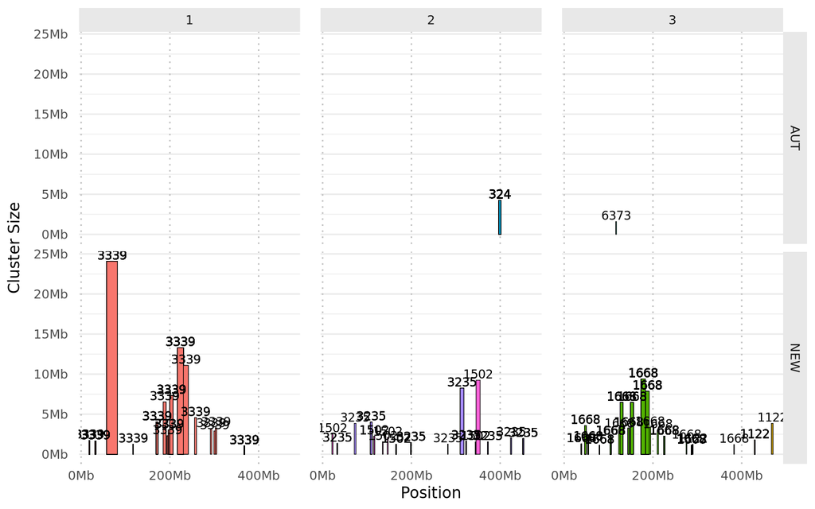

```r
# Merge SNP counts into results
results_with_counts <- merge(results, snp_counts, by = c("Population", "Chromosome", "Cluster"))

ggplot(results_with_counts, aes(xmin = Start, xmax = End, ymin = 0, ymax = Size)) +
  geom_rect(aes(fill = as.factor(Cluster)), color = "black", linewidth = 0.2) +
  geom_text(aes(x = (Start + End) / 2, y = Size + 0.5, label = SNP_Count), size = 3, vjust = -0.2) + # Annotate SNP counts on top
  scale_x_continuous(labels = label_mb, breaks = pretty_breaks(n = 3)) +
  scale_y_continuous(labels = label_mb, breaks = pretty_breaks(n = 5)) +
  labs(x = "Position", y = "Cluster Size") +
  theme_minimal() +
  theme(
    axis.text.y = element_text(margin = margin(t = 0, r = 5, b = 0, l = 5)),
    axis.ticks.y = element_blank(),
    panel.grid.major.x = element_line(color = "gray", linetype = "dotted"),
    strip.background = element_rect(fill = "#e8e8e8", colour = NA),
    panel.grid.minor.x = element_blank(),
    legend.position = "none",
    panel.spacing.x = unit(1, "lines")
  ) +
  facet_grid(Population ~ Chromosome, scales = "fixed", space = "fixed") +
  guides(fill = "none")
```

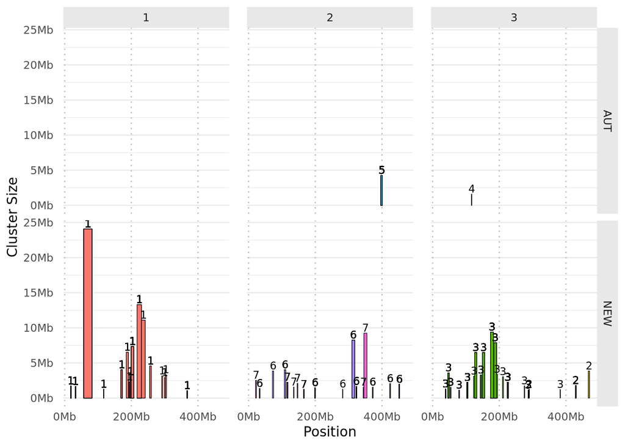

```r
# 1. Generate integer IDs for each cluster in plotting order
cluster_ids <- data.frame(
  Cluster     = sort(unique(results$Cluster)),
  Cluster_ID  = seq_along(unique(results$Cluster))
)

# 2. Merge IDs into your results
results_with_ids <- merge(results, cluster_ids, by = "Cluster")

# 3. Plot, labeling by your original 1,2,3,… IDs
ggplot(results_with_ids, aes(xmin = Start, xmax = End, ymin = 0, ymax = Size)) +
  geom_rect(aes(fill = factor(Cluster_ID)), color = "black", linewidth = 0.2) +
  geom_text(aes(x = (Start + End) / 2,
                y = Size + 0.5,
                label = Cluster_ID),
            size = 3, vjust = -0.2) +
  scale_x_continuous(labels = label_mb, breaks = pretty_breaks(n = 3)) +
  scale_y_continuous(labels = label_mb, breaks = pretty_breaks(n = 5)) +
  labs(x = "Position", y = "Cluster Size") +
  theme_minimal() +
  theme(
    axis.text.y        = element_text(margin = margin(t = 0, r = 5)),
    axis.ticks.y       = element_blank(),
    panel.grid.major.x = element_line(color = "gray", linetype = "dotted"),
    strip.background   = element_rect(fill = "#e8e8e8", colour = NA),
    panel.grid.minor.x = element_blank(),
    legend.position    = "none",
    panel.spacing.x    = unit(1, "lines")
  ) +
  facet_grid(Population ~ Chromosome, scales = "fixed", space = "fixed") +
  guides(fill = "none")
```

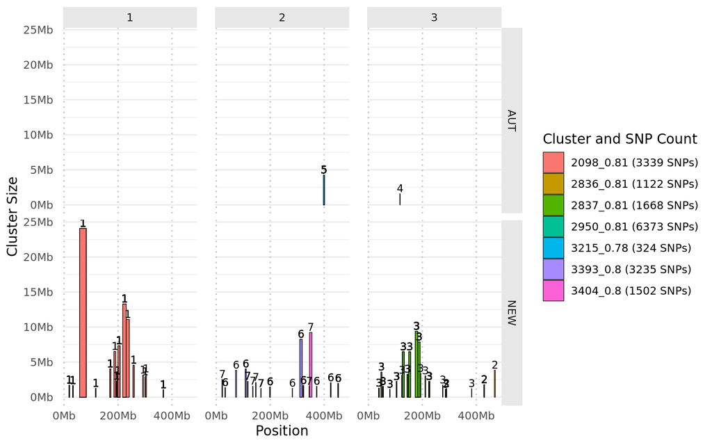

```r
# 1. Merge integer IDs into your SNP‐counted data
cluster_ids <- data.frame(
  Cluster    = sort(unique(results_with_counts$Cluster)),
  Cluster_ID = seq_along(unique(results_with_counts$Cluster))
)
results_with_counts <- merge(results_with_counts, cluster_ids, by = "Cluster")

# 2. Build the fill label
results_with_counts$Cluster_SNP <- with(
  results_with_counts,
  paste0(Cluster, " (", SNP_Count, " SNPs)")
)

# 3. Plot with fill by SNP count label and text by cluster ID
ggplot(results_with_counts, aes(xmin = Start, xmax = End, ymin = 0, ymax = Size)) +
  geom_rect(aes(fill = Cluster_SNP), color = "black", linewidth = 0.2) +
  geom_text(
    aes(x = (Start + End) / 2, y = Size + 0.5, label = Cluster_ID),
    size = 3, vjust = -0.2
  ) +
  scale_fill_discrete(name = "Cluster and SNP Count") +
  scale_x_continuous(labels = label_mb, breaks = pretty_breaks(n = 3)) +
  scale_y_continuous(labels = label_mb, breaks = pretty_breaks(n = 5)) +
  labs(x = "Position", y = "Cluster Size") +
  theme_minimal() +
  theme(
    axis.text.y        = element_text(margin = margin(t = 0, r = 5)),
    axis.ticks.y       = element_blank(),
    panel.grid.major.x = element_line(color = "gray", linetype = "dotted"),
    strip.background   = element_rect(fill = "#e8e8e8", colour = NA),
    panel.grid.minor.x = element_blank(),
    legend.position    = "right",
    panel.spacing.x    = unit(1, "lines")
  ) +
  facet_grid(Population ~ Chromosome, scales = "fixed", space = "fixed")
```

Save

```r
saveRDS(results_with_counts, file = here("output", "ldna", "results_with_counts.rds"))
```

Read the data

```r
results_with_counts <- readRDS(file = here("output", "ldna", "results_with_counts.rds"))
```

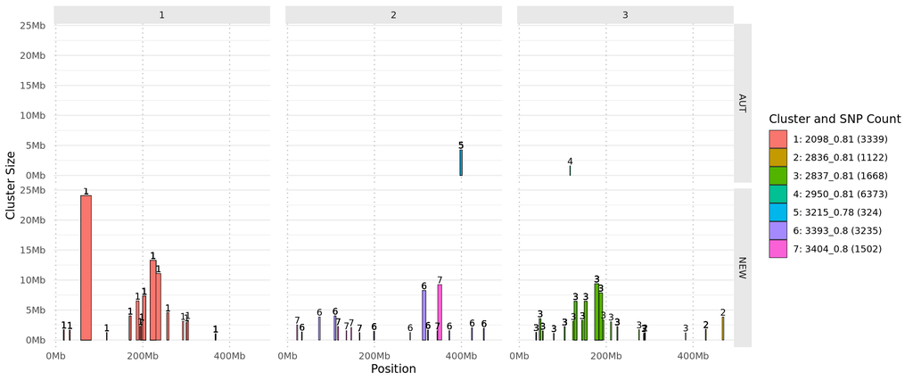

```r
# Rebuild the fill label: add ID before Cluster and drop “ SNPs”
results_with_counts$Cluster_SNP <- with(
  results_with_counts,
  paste0(Cluster_ID, ": ", Cluster, " (", SNP_Count, ")")
)

# 1. Reorder Cluster_SNP factor by Cluster_ID so the legend follows numeric order
results_with_counts$Cluster_SNP <- factor(
  results_with_counts$Cluster_SNP,
  levels = results_with_counts %>%
    distinct(Cluster_ID, Cluster_SNP) %>%
    arrange(Cluster_ID) %>%
    pull(Cluster_SNP)
)

# 2. Plot with sorted legend
ggplot(results_with_counts, aes(xmin = Start, xmax = End, ymin = 0, ymax = Size)) +
  geom_rect(aes(fill = Cluster_SNP), color = "black", linewidth = 0.2) +
  geom_text(
    aes(x = (Start + End) / 2, y = Size + 0.5, label = Cluster_ID),
    size = 3, vjust = -0.2
  ) +
  scale_fill_discrete(name = "Cluster and SNP Count") +
  scale_x_continuous(labels = label_mb, breaks = pretty_breaks(n = 3)) +
  scale_y_continuous(labels = label_mb, breaks = pretty_breaks(n = 5)) +
  labs(x = "Position", y = "Cluster Size") +
  theme_minimal() +
  theme(
    axis.text.y        = element_text(margin = margin(t = 0, r = 5)),
    axis.ticks.y       = element_blank(),
    panel.grid.major.x = element_line(color = "gray", linetype = "dotted"),
    strip.background   = element_rect(fill = "#e8e8e8", colour = NA),
    panel.grid.minor.x = element_blank(),
    legend.position    = "right",
    panel.spacing.x    = unit(1, "lines")
  ) +
  facet_grid(Population ~ Chromosome, scales = "fixed", space = "fixed")
```

```r
# Use ggsave to save the plot as a PDF
ggsave(
  filename = here("output", "ldna", "AUT_NEW_non_overlapping_clusters_with_SNPs_on_DE_genes.pdf"),
  device = "pdf",
  width = 10,
  height = 5,
  units = "in"
)
```

Save it

```r
library(writexl)

# 1. Drop Cluster_ID column(s)
cleaned_results <- results_with_counts %>%
  select(-starts_with("Cluster_ID")) %>%
  mutate(
    Start        = formatC(Start,        format = "f", digits = 0),
    End          = formatC(End,          format = "f", digits = 0),
    Position_chr = formatC(Position_chr, format = "f", digits = 0)
  )


# 2. Export cleaned results_with_counts to Excel
write_xlsx(
  list(Results = cleaned_results),
  here("output/ldna/results_with_counts.xlsx")
)
```

Now we can get the SNPs on the DE genes

```r
snps79_DE_genes<- read_delim(here("output", "snpeff","SNPs_79_DE.txt"), delim = "\t", col_names = FALSE, show_col_types = FALSE)
head(snps79_DE_genes)
```

```
## # A tibble: 6 x 1
##   X1
##   <chr>
## 1 AX-583054970
## 2 AX-583055828
## 3 AX-583093532
## 4 AX-583142560
## 5 AX-583237406
## 6 AX-583279927
```

Or the SNPs from the selection scan

```r
snps_selection <- read_delim(here("output", "pcadapt","outlier_157_SNPs.txt"), delim = "\t", col_names = FALSE, show_col_types = FALSE)
head(snps_selection)
```

```
## # A tibble: 6 x 1
##   X1
##   <chr>
## 1 AX-583054970
## 2 AX-583095890
## 3 AX-583324654
## 4 AX-583423493
## 5 AX-583426050
## 6 AX-583467551
```

Filter

```r
# Create a logical vector to filter rows based on SNP IDs
filter_vector <- results_with_counts$SNP %in% snps79_DE_genes$X1
# filter_vector <- results_with_counts$SNP %in% snps_selection$X1  # we do not have any

# Subset results_with_counts to keep only rows where SNP matches
filtered_results <- results_with_counts[filter_vector, ]

head(filtered_results)
```

```
##      Cluster Population Chromosome   r2 nSegments nSNPs     Start       End
## 6  2098_0.81        NEW          1 0.81       225  3339  17763447  19491473
## 16 2098_0.81        NEW          1 0.81       225  3339  31462771  33110064
## 19 2098_0.81        NEW          1 0.81       225  3339  57603304  81674467
## 23 2098_0.81        NEW          1 0.81       225  3339  57603304  81674467
## 52 2098_0.81        NEW          1 0.81       225  3339 199758742 207076243
## 57 2098_0.81        NEW          1 0.81       225  3339 199758742 207076243
##        Size   SizeMb          SNP Position_chr SNP_Count Cluster_ID
## 6   1728026  1728026 AX-583093532     18373267      3339          1
## 16  1647293  1647293 AX-583142560     33012482      3339          1
## 19 24071163 24071163 AX-583237406     66299838      3339          1
## 23 24071163 24071163 AX-583279927     80133483      3339          1
## 52  7317501  7317501 AX-583696963    199917250      3339          1
## 57  7317501  7317501 AX-583709904    206309664      3339          1
##            Cluster_SNP
## 6  1: 2098_0.81 (3339)
## 16 1: 2098_0.81 (3339)
## 19 1: 2098_0.81 (3339)
## 23 1: 2098_0.81 (3339)
## 52 1: 2098_0.81 (3339)
## 57 1: 2098_0.81 (3339)
```

```r
# length(filtered_results)
```

We have 16 SNPs

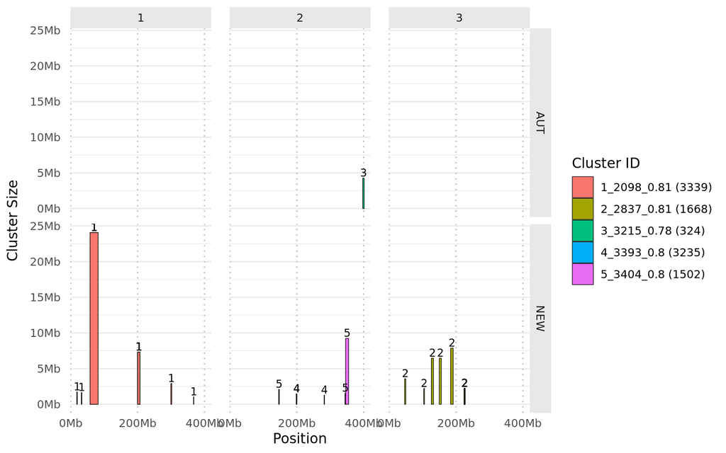

```r
# Assign unique numbers to each cluster and create labels
filtered_results <- filtered_results %>%
  mutate(Cluster_Number = as.numeric(as.factor(Cluster))) %>%
  arrange(Cluster_Number) %>%
  mutate(Cluster_Label = paste(Cluster_Number, "_", Cluster, " (", SNP_Count, ")", sep=""))

# Reorder the factor levels of Cluster_Label based on Cluster_Number
filtered_results$Cluster_Label <- factor(filtered_results$Cluster_Label,
                                            levels = unique(filtered_results$Cluster_Label[order(filtered_results$Cluster_Number)]))

# Plotting
ggplot(filtered_results, aes(xmin = Start, xmax = End, ymin = 0, ymax = Size)) +
  geom_rect(aes(fill = Cluster_Label), color = "black", linewidth = 0.2) +
  geom_text(aes(x = (Start + End) / 2, y = Size + 0.5, label = Cluster_Number), size = 3, vjust = -0.2) +
  scale_fill_discrete(name = "Cluster ID") +
  scale_x_continuous(labels = label_mb, breaks = pretty_breaks(n = 3)) +
  scale_y_continuous(labels = label_mb, breaks = pretty_breaks(n = 5)) +
  labs(x = "Position", y = "Cluster Size") +
  theme_minimal() +
  theme(
    axis.text.y = element_text(margin = margin(t = 0, r = 5, b = 0, l = 5)),
    axis.ticks.y = element_blank(),
    panel.grid.major.x = element_line(color = "gray", linetype = "dotted"),
    strip.background = element_rect(fill = "#e8e8e8", colour = NA),
    panel.grid.minor.x = element_blank(),
    legend.position = "right",
    panel.spacing.x = unit(1, "lines")
  ) +
  facet_grid(Population ~ Chromosome, scales = "fixed", space = "fixed")
```

```r
# Use ggsave to save the plot as a PDF
ggsave(
  filename = here("output", "ldna", "AUT_NEW_overlapping_clusters_with_SNPs_on_DE_genes_intersect.pdf"),
  device = "pdf",
  width = 10,
  height = 5,
  units = "in"
)
```

This are the clusters for which we found the SNP as outlier and the gene the SNP in on is DE

Get the overlapping clusters

```r
# Function to find overlapping clusters
find_overlapping_clusters <- function(population1, population2) {
  overlapping_clusters <- list()

  for (chr in unique(population1$Chromosome)) {
    pop1_chrom_clusters <- population1[population1$Chromosome == chr, ]
    pop2_chrom_clusters <- population2[population2$Chromosome == chr, ]

    overlapping_clusters_chr <- list()

    for (i in 1:nrow(pop1_chrom_clusters)) {
      for (j in 1:nrow(pop2_chrom_clusters)) {
        if (pop1_chrom_clusters$Start[i] <= pop2_chrom_clusters$End[j] &&
            pop1_chrom_clusters$End[i] >= pop2_chrom_clusters$Start[j]) {
          overlapping_clusters_chr <- c(overlapping_clusters_chr, list(pop1_chrom_clusters[i, ]))
          break
        }
      }
    }

    if (length(overlapping_clusters_chr) > 0) {
      overlapping_clusters[[chr]] <- do.call(rbind, overlapping_clusters_chr)
    }
  }

  do.call(rbind, overlapping_clusters)
}

# Subset data for NEW and AUT populations
albo_NEW <- subset(albo2, Population == "NEW")
albo_AUT <- subset(albo2, Population == "AUT")

# Find overlapping clusters between NEW and AUT
overlapping_clusters <- find_overlapping_clusters(albo_NEW, albo_AUT)

# View the overlapping clusters
overlapping_clusters
```

```
##     Population Chromosome   Cluster   r2 nSegments nSNPs     Start       End
## 66         NEW          1 2098_0.81 0.81       225  3339   1671072  16303506
## 76         NEW          1 2257_0.78 0.78        21    49  88409052  90437664
## 82         NEW          1 2098_0.81 0.81       225  3339 118382563 133808459
## 83         NEW          1 2098_0.81 0.81       225  3339 134311499 152641345
## 86         NEW          1 2098_0.81 0.81       225  3339 175562655 184285228
## 95         NEW          1 2098_0.81 0.81       225  3339 241581708 245964256
## 96         NEW          1 2098_0.81 0.81       225  3339 246194066 250559827
## 101        NEW          1 2098_0.81 0.81       225  3339 263937222 271417059
## 102        NEW          1 2098_0.81 0.81       225  3339 274018327 291005909
## 137        NEW          2  3393_0.8  0.8      1027  3235 100600773 102052192
## 142        NEW          2  3404_0.8  0.8       905  1502 129752494 132084935
## 144        NEW          2  3393_0.8  0.8      1027  3235 137286537 138732635
## 145        NEW          2  3404_0.8  0.8       905  1502 141517826 144428065
## 148        NEW          2  3404_0.8  0.8       905  1502 149738780 153093408
```

[output cut: 55 more lines]

Plot it

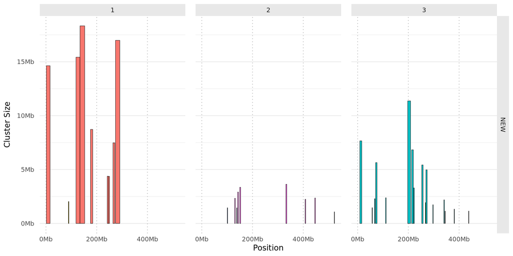

```r
# Function to format numbers as Mb
label_mb <- function(x) {
  sprintf("%.0fMb", x / 1e6)
}

# Plot it
ggplot(overlapping_clusters, aes(xmin = Start, xmax = End, ymin = 0, ymax = Size)) +
  geom_rect(aes(fill = as.factor(Cluster)), color = "black", linewidth = 0.2) +
  scale_x_continuous(labels = label_mb, breaks = pretty_breaks(n = 3)) +
  scale_y_continuous(labels = label_mb, breaks = pretty_breaks(n = 5)) +
  labs(x = "Position", y = "Cluster Size") +
  theme_minimal() +
  theme(
    axis.text.y = element_text(margin = margin(t = 0, r = 5, b = 0, l = 5)),
    axis.ticks.y = element_blank(),
    panel.grid.major.x = element_line(color = "gray", linetype = "dotted"),
    strip.background = element_rect(fill = "#e8e8e8", colour = NA),
    panel.grid.minor.x = element_blank(),
    legend.position = "none",
    panel.spacing.x = unit(1, "lines")  # Adjust the unit and number to increase space as needed
  ) +
  facet_grid(Population ~ Chromosome, scales = "fixed", space = "fixed") +
  guides(fill = "none")
```

```r
# Use ggsave to save the plot as a PDF
ggsave(
  filename = here("output", "ldna", "AUT_NEW_fixed_overlapping.pdf"),
  device = "pdf",
  width = 10,
  height = 5,
  units = "in"
)
```